# Practical Machine Learning: Peer Assessment: Predicting accuracy of barbell lifts using accelerometer data

```r
knitr::opts_chunk$set(fig.height=4, fig.path='figure/',
                      echo=TRUE, warning=FALSE, message=FALSE)
```

## Synopsis

Below is an example of using the Caret package in R to train data and predict the type of barbell lift performed by using data from accelerometers on the belt, forearm, arm, and dumbell of 6 participants (information is available from the website here: http://groupware.les.inf.puc-rio.br/har). A random forest approach was used on a training, test, and validation data set using cross validation to make the predictions which were > 99% accurate in the test set, and 100% correct in quiz 4.

## Data Processing

```r
library(caret)
quiz <- read.csv("pml-testing.csv",na.strings=c("","NA","#DIV/0!"))
data <- read.csv("pml-training.csv",na.strings=c("","NA","#DIV/0!"))
inTrain <- createDataPartition(y=data$classe,p=.7,list=FALSE)
data <- data[, colSums(is.na(data)) < 0.5*nrow(data)]
qdata <- quiz[, colSums(is.na(quiz)) < 0.5*nrow(quiz)]
training <- data[inTrain,]
testing <- data[-inTrain,]
training <- training[,-c(1:7)]
testing <- testing[,-c(1:7)]
qdata <- qdata[,-c(1:7)]
```

The training set was split into 70% training and 30% test. The data required much cleaning–many of the 160 variables in the data set were populated with >50% NA values which were removed. In addition, the first 7 columns of the data were removed as they were deemed not relevant to the prediction model (subject name, timestamp, etc). The resulting data contained 52 predictors.

### Training Data & Results

```r
modFit2 <- train(classe~.,method="rf",data=training,na.action=na.exclude)
modFit2
modFit2$finalModel
```

[output not shown]

```r
library(caret)
mymodel <- get(load(file="/Users/steph/Desktop/coursera/modFitrf.Rdata"))
Pred <- predict(mymodel,testing)
testing$predRight <- Pred==testing$classe
confusionMatrix(testing$classe,predict(mymodel,testing))
```

```
## Confusion Matrix and Statistics
##
##           Reference
## Prediction    A    B    C    D    E
##          A 1673    0    0    0    1
##          B    3 1136    0    0    0
##          C    0    3 1022    1    0
##          D    0    0    5  959    0
##          E    0    0    0    0 1082
##
## Overall Statistics
##
##                Accuracy : 0.9978
##                  95% CI : (0.9962, 0.9988)
##     No Information Rate : 0.2848
##     P-Value [Acc > NIR] : < 2.2e-16
##
##                   Kappa : 0.9972
##  Mcnemar's Test P-Value : NA
##
## Statistics by Class:
##
##                      Class: A Class: B Class: C Class: D Class: E
## Sensitivity            0.9982   0.9974   0.9951   0.9990   0.9991
## Specificity            0.9998   0.9994   0.9992   0.9990   1.0000
## Pos Pred Value         0.9994   0.9974   0.9961   0.9948   1.0000
## Neg Pred Value         0.9993   0.9994   0.9990   0.9998   0.9998
## Prevalence             0.2848   0.1935   0.1745   0.1631   0.1840
## Detection Rate         0.2843   0.1930   0.1737   0.1630   0.1839
## Detection Prevalence   0.2845   0.1935   0.1743   0.1638   0.1839
## Balanced Accuracy      0.9990   0.9984   0.9972   0.9990   0.9995
```

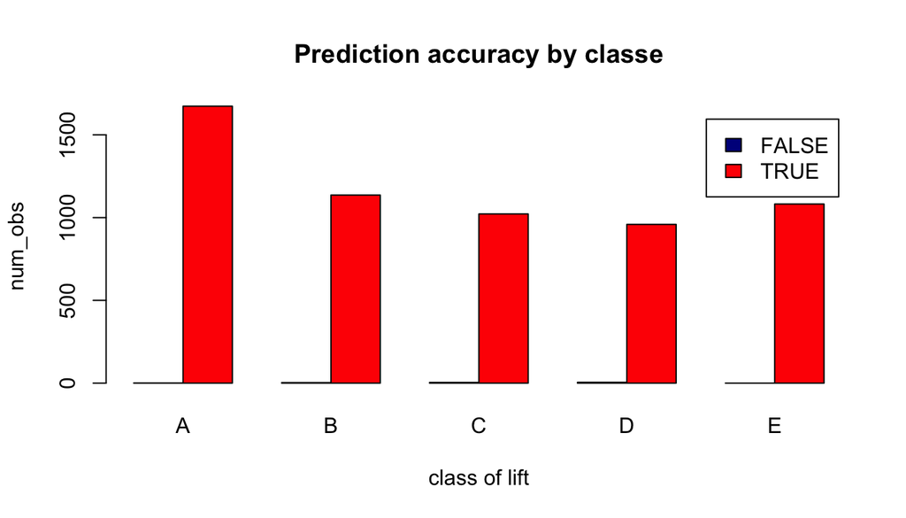

```r
counts <- table(testing$predRight,testing$classe)
barplot(counts,main="Prediction accuracy by classe",
  xlab="class of lift", ylab="num_obs",col=c("darkblue","red"),
    legend = rownames(counts), beside=TRUE)
```